# Hormones, Normal vs. Premature Adrenarch

Bonald Figueiredo, Enzo Lalli, and [Henrique Laureano](https://henriquelaureano.github.io/)

Last modification on* 2022-04-14 09:56:44

# Premature adrenarch

## Age

> 10 kids with age available.

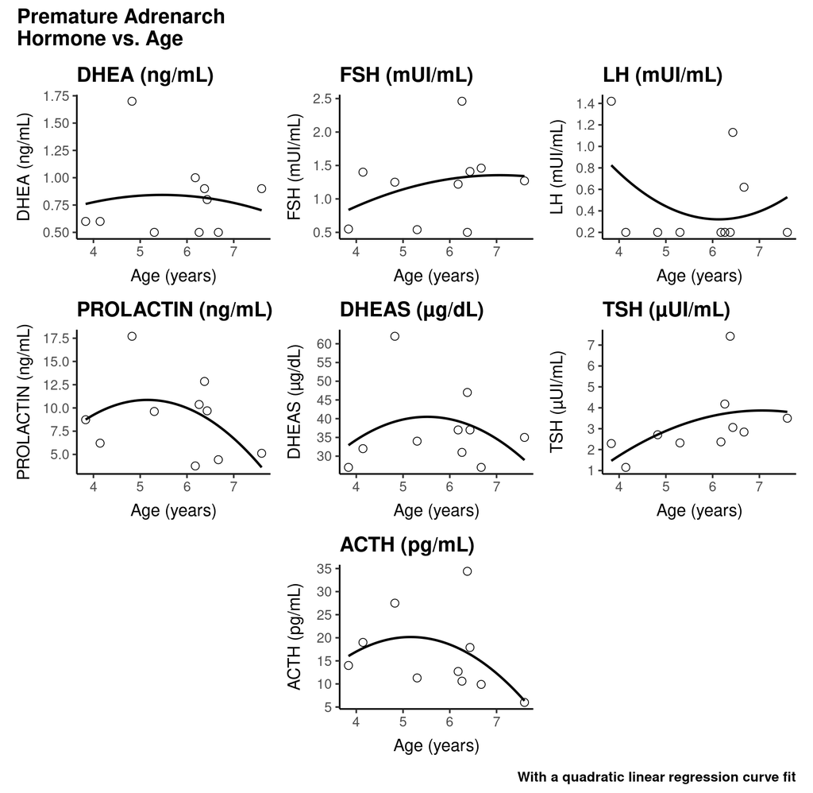

## BMI

> 7 kids with BMI available.

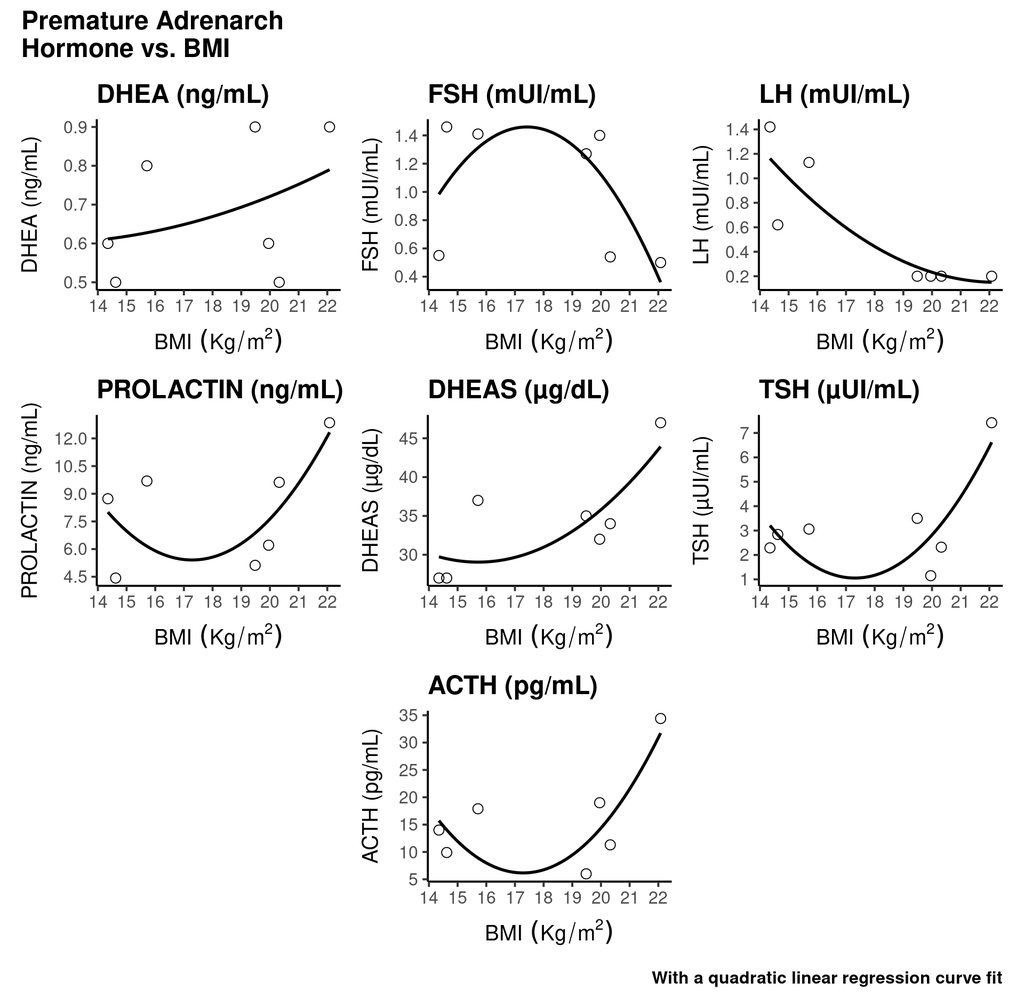

# Normal Adrenarch

## Age

> 129 kids with 3 $\leq$ age $\leq$ 8 and DHEAS (ug/dL) $\leq$ 25 available.

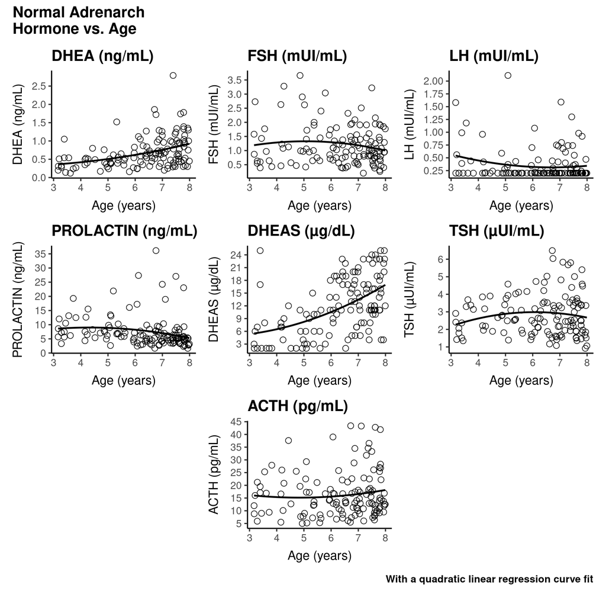

## BMI

> 113 kids with 3 $\leq$ age $\leq$ 8, DHEAS (ug/dL) $\leq$ 25, and BMI available.

> Two kids have huge and discrepant BMI values. Delete/remove them?

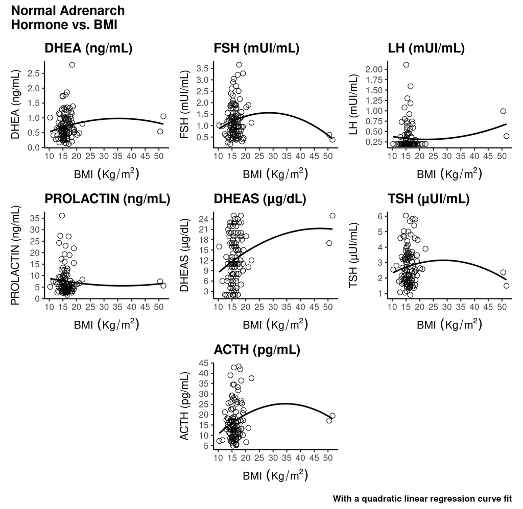

# DHEA (ng/mL)

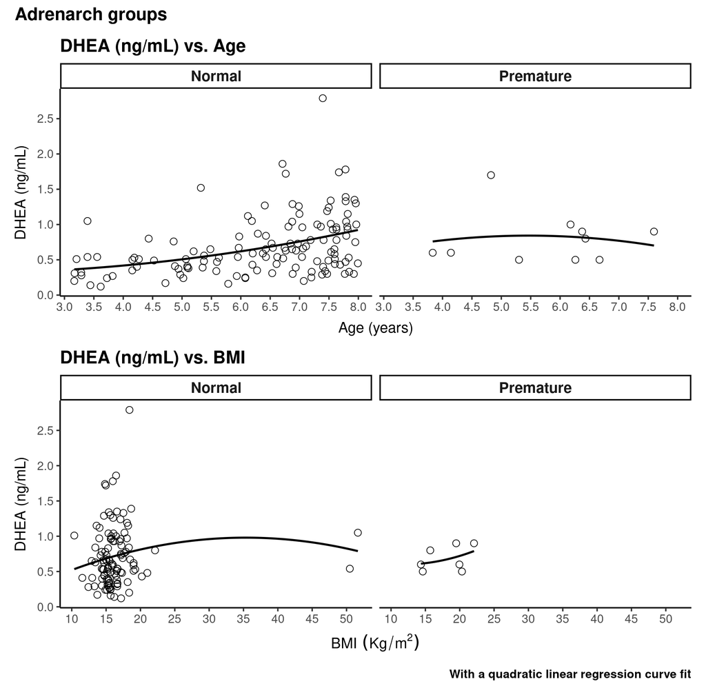

# FSH (mUI/mL)

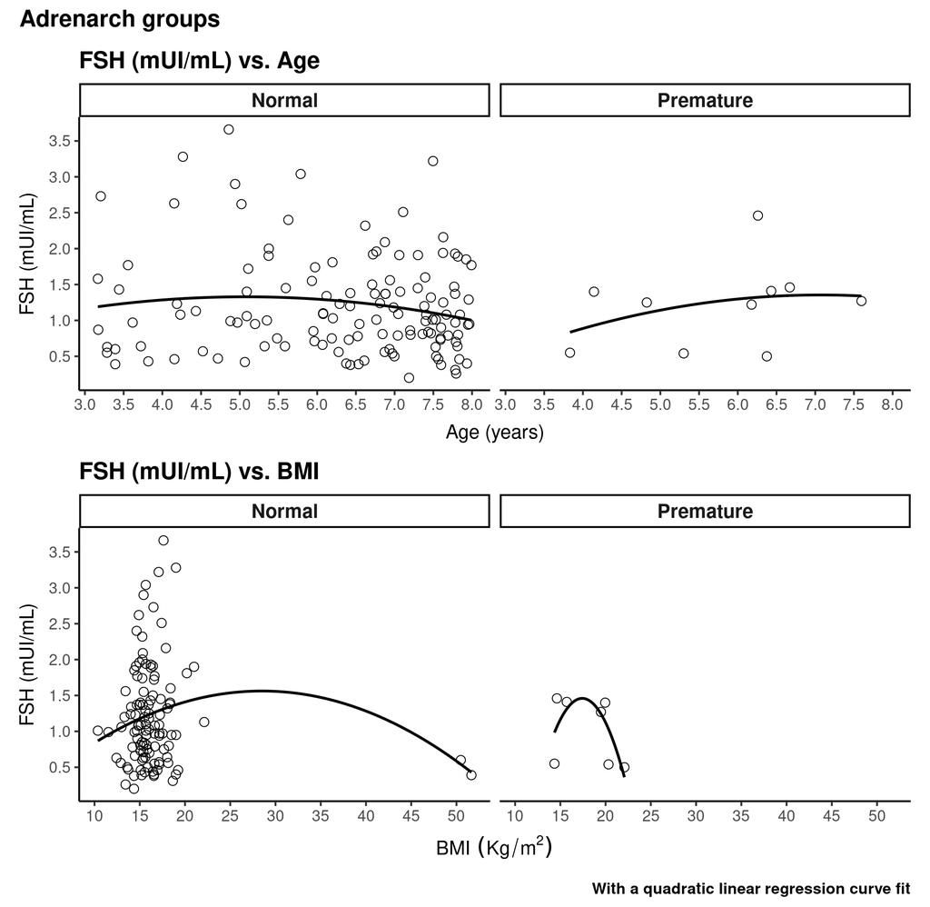

# LH (mUI/mL)

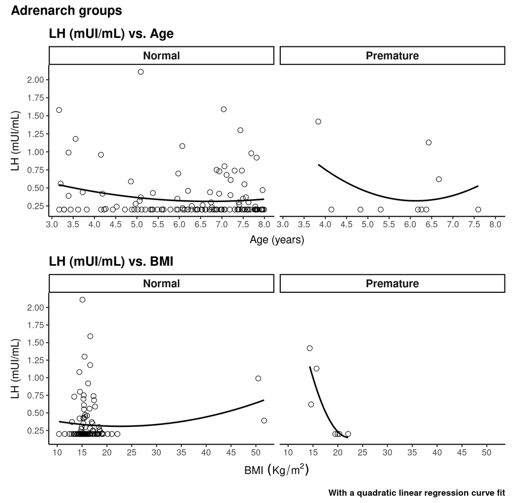

# PROLACTIN (ng/mL)

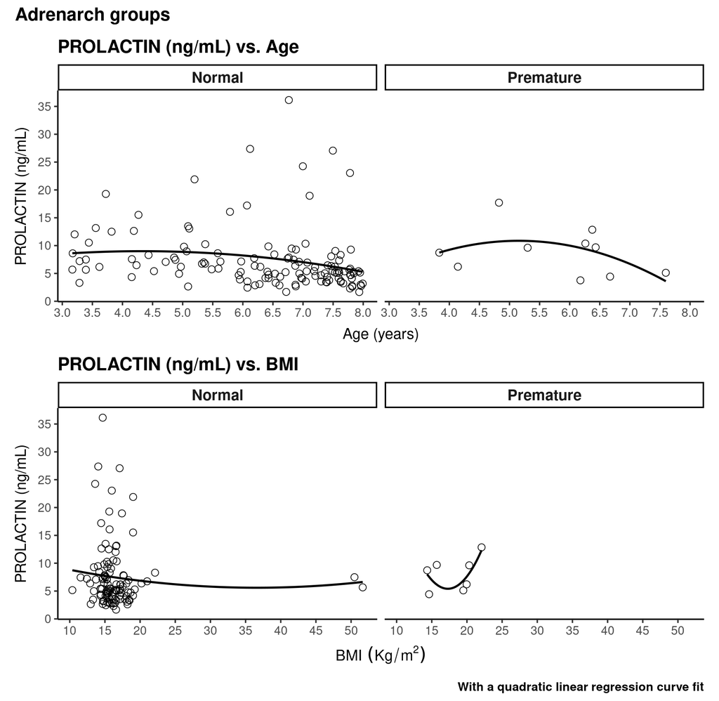

# DHEAS (µg/dL)

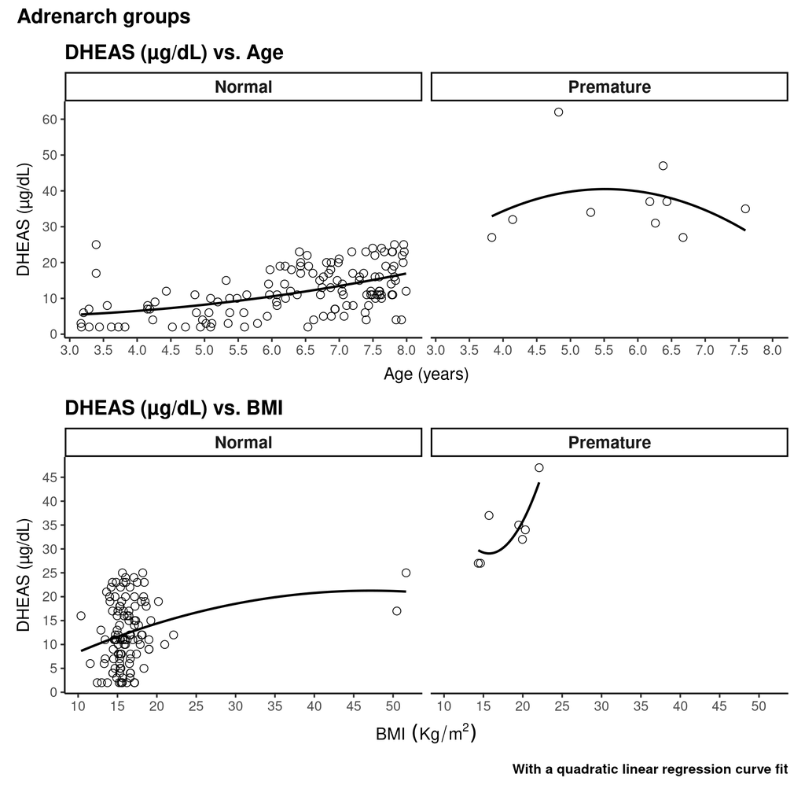

# TSH (µUI/mL)

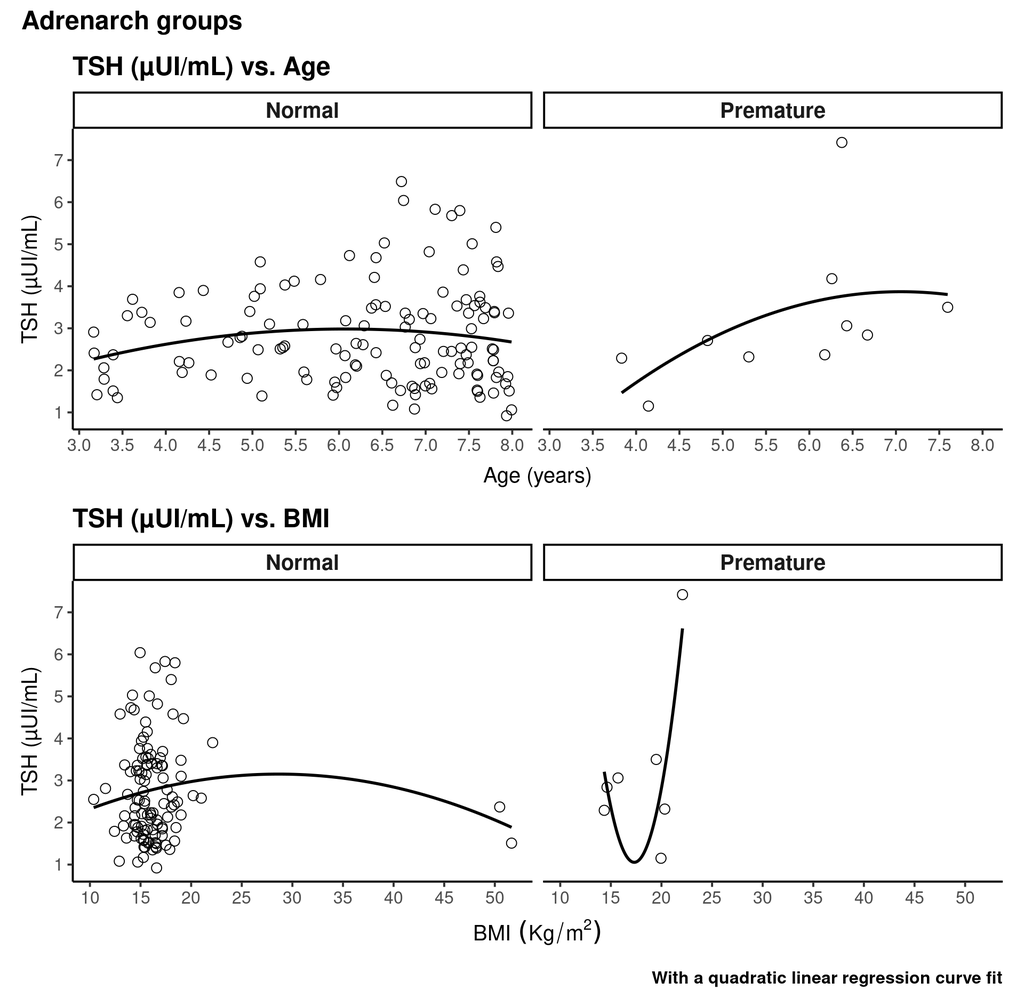

# ACTH (pg/mL)

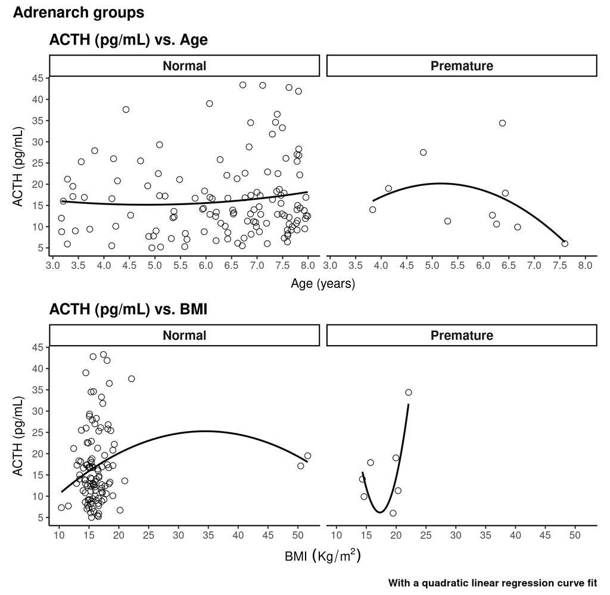

# PROLACTION x DHEA

> Computing and testing the correlation (Pearson’s) statistical significance, in each Adrenarch group.

| Adrenarch | Correlation | Conf.low | Conf.high | N | Statistic | p-value | Test | H1 |
| --- | --- | --- | --- | --- | --- | --- | --- | --- |
| Premature | 0.57708 | -0.08253 | 0.88511 | 10 | 1.99861 | 0.08069 | Pearson’s product-moment correlation | two.sided |
| Normal | 0.01065 | -0.16318 | 0.18384 | 128 | 0.11960 | 0.90499 | Pearson’s product-moment correlation | two.sided |

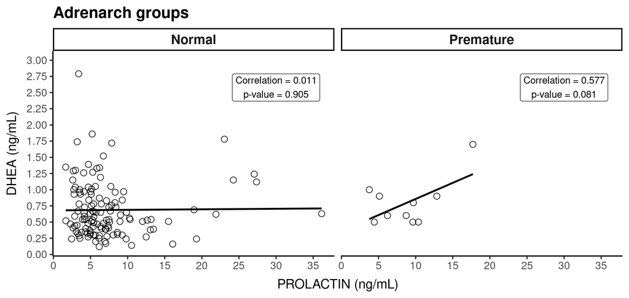

# PROLACTIN x DHEAS

> Computing and testing the correlation (Pearson’s) statistical significance, in each Adrenarch group.

| Adrenarch | Correlation | Conf.low | Conf.high | N | Statistic | p-value | Test | H1 |
| --- | --- | --- | --- | --- | --- | --- | --- | --- |
| Premature | 0.77999 | 0.29546 | 0.94535 | 10 | 3.52531 | 0.00779 | Pearson’s product-moment correlation | two.sided |
| Normal | -0.15033 | -0.31500 | 0.02312 | 129 | -1.71364 | 0.08904 | Pearson’s product-moment correlation | two.sided |

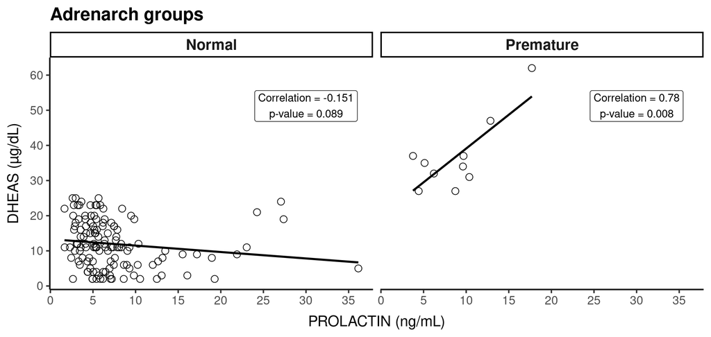

# PROLACTIN x FSH

> Computing and testing the correlation (Pearson’s) statistical significance, in each Adrenarch group.

| Adrenarch | Correlation | Conf.low | Conf.high | N | Statistic | p-value | Test | H1 |
| --- | --- | --- | --- | --- | --- | --- | --- | --- |
| Premature | -0.12126 | -0.69762 | 0.55039 | 10 | -0.34553 | 0.73861 | Pearson’s product-moment correlation | two.sided |
| Normal | 0.17618 | 0.00343 | 0.33871 | 129 | 2.01694 | 0.04581 | Pearson’s product-moment correlation | two.sided |

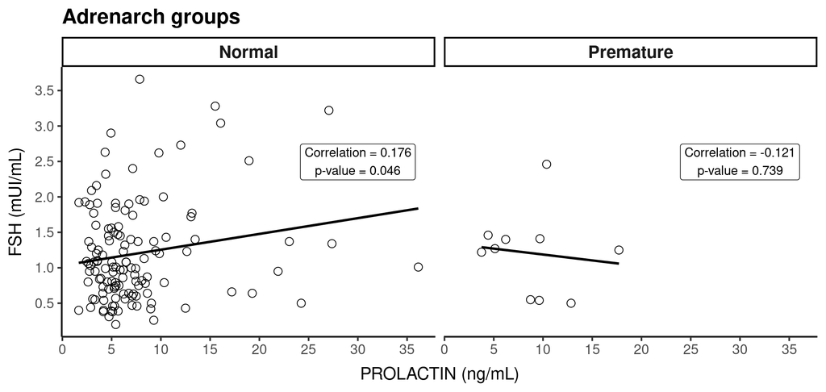

# PROLACTIN x LH

> Computing and testing the correlation (Pearson’s) statistical significance, in each Adrenarch group.

| Adrenarch | Correlation | Conf.low | Conf.high | N | Statistic | p-value | Test | H1 |
| --- | --- | --- | --- | --- | --- | --- | --- | --- |
| Premature | -0.06953 | -0.66983 | 0.58574 | 10 | -0.19714 | 0.84864 | Pearson’s product-moment correlation | two.sided |
| Normal | 0.08042 | -0.09374 | 0.24980 | 129 | 0.90923 | 0.36495 | Pearson’s product-moment correlation | two.sided |

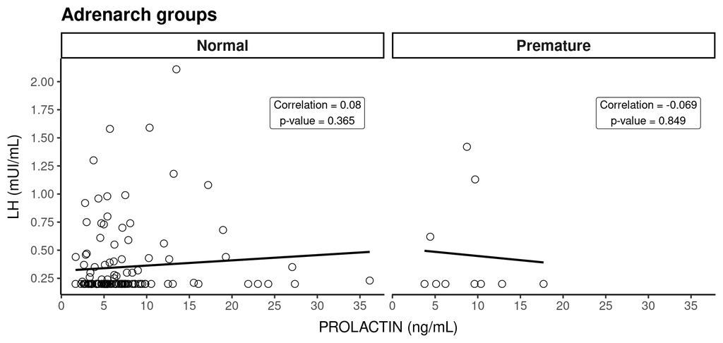

# PROLACTIN x TSH

> Computing and testing the correlation (Pearson’s) statistical significance, in each Adrenarch group.

| Adrenarch | Correlation | Conf.low | Conf.high | N | Statistic | p-value | Test | H1 |
| --- | --- | --- | --- | --- | --- | --- | --- | --- |
| Premature | 0.36045 | -0.34820 | 0.80694 | 10 | 1.09297 | 0.30622 | Pearson’s product-moment correlation | two.sided |
| Normal | 0.12532 | -0.04858 | 0.29185 | 129 | 1.42354 | 0.15703 | Pearson’s product-moment correlation | two.sided |

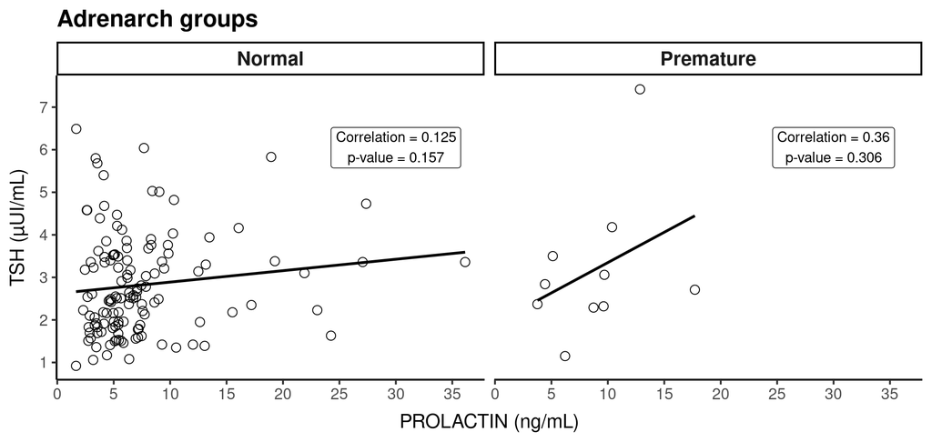

# PROLACTIN x ACTH

> Computing and testing the correlation (Pearson’s) statistical significance, in each Adrenarch group.

| Adrenarch | Correlation | Conf.low | Conf.high | N | Statistic | p-value | Test | H1 |
| --- | --- | --- | --- | --- | --- | --- | --- | --- |
| Premature | 0.71067 | 0.14667 | 0.92597 | 10 | 2.85715 | 0.02124 | Pearson’s product-moment correlation | two.sided |
| Normal | 0.20095 | 0.02911 | 0.36126 | 129 | 2.31174 | 0.02240 | Pearson’s product-moment correlation | two.sided |

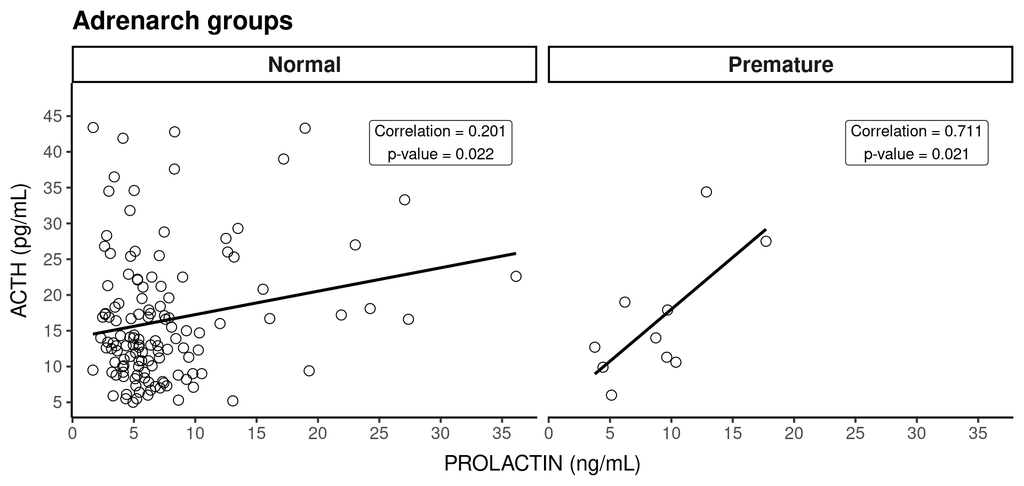

# FSH x DHEA

> Computing and testing the correlation (Pearson’s) statistical significance, in each Adrenarch group.

| Adrenarch | Correlation | Conf.low | Conf.high | N | Statistic | p-value | Test | H1 |
| --- | --- | --- | --- | --- | --- | --- | --- | --- |
| Premature | -0.09366 | -0.68301 | 0.56955 | 10 | -0.26609 | 0.79690 | Pearson’s product-moment correlation | two.sided |
| Normal | -0.00949 | -0.18272 | 0.16431 | 128 | -0.10650 | 0.91535 | Pearson’s product-moment correlation | two.sided |

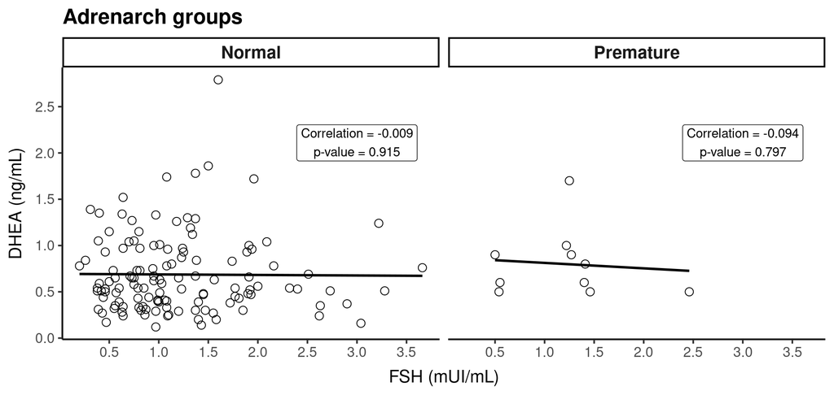

# LH x DHEA

> Computing and testing the correlation (Pearson’s) statistical significance, in each Adrenarch group.

| Adrenarch | Correlation | Conf.low | Conf.high | N | Statistic | p-value | Test | H1 |
| --- | --- | --- | --- | --- | --- | --- | --- | --- |
| Premature | -0.24502 | -0.75775 | 0.45477 | 10 | -0.71479 | 0.49506 | Pearson’s product-moment correlation | two.sided |
| Normal | -0.13668 | -0.30303 | 0.03774 | 128 | -1.54882 | 0.12393 | Pearson’s product-moment correlation | two.sided |

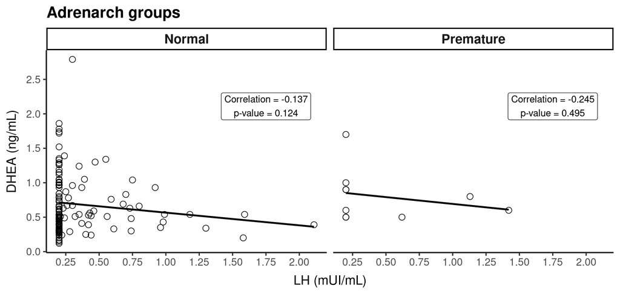

# TSH x DHEA

> Computing and testing the correlation (Pearson’s) statistical significance, in each Adrenarch group.

| Adrenarch | Correlation | Conf.low | Conf.high | N | Statistic | p-value | Test | H1 |
| --- | --- | --- | --- | --- | --- | --- | --- | --- |
| Premature | 0.09190 | -0.57075 | 0.68206 | 10 | 0.26104 | 0.80065 | Pearson’s product-moment correlation | two.sided |
| Normal | 0.10515 | -0.06965 | 0.27369 | 128 | 1.18689 | 0.23750 | Pearson’s product-moment correlation | two.sided |

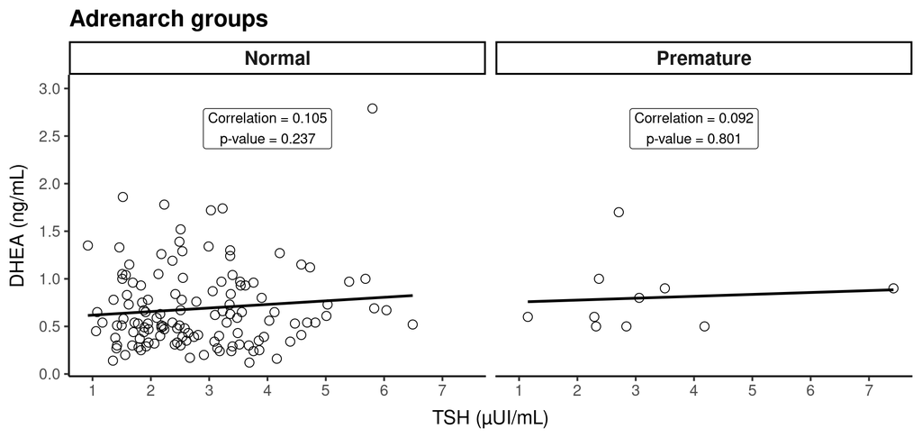

# ACTH x DHEA

> Computing and testing the correlation (Pearson’s) statistical significance, in each Adrenarch group.

| Adrenarch | Correlation | Conf.low | Conf.high | N | Statistic | p-value | Test | H1 |
| --- | --- | --- | --- | --- | --- | --- | --- | --- |
| Premature | 0.52519 | -0.15603 | 0.86784 | 10 | 1.74558 | 0.11903 | Pearson’s product-moment correlation | two.sided |
| Normal | 0.22876 | 0.05751 | 0.38693 | 128 | 2.63778 | 0.00940 | Pearson’s product-moment correlation | two.sided |

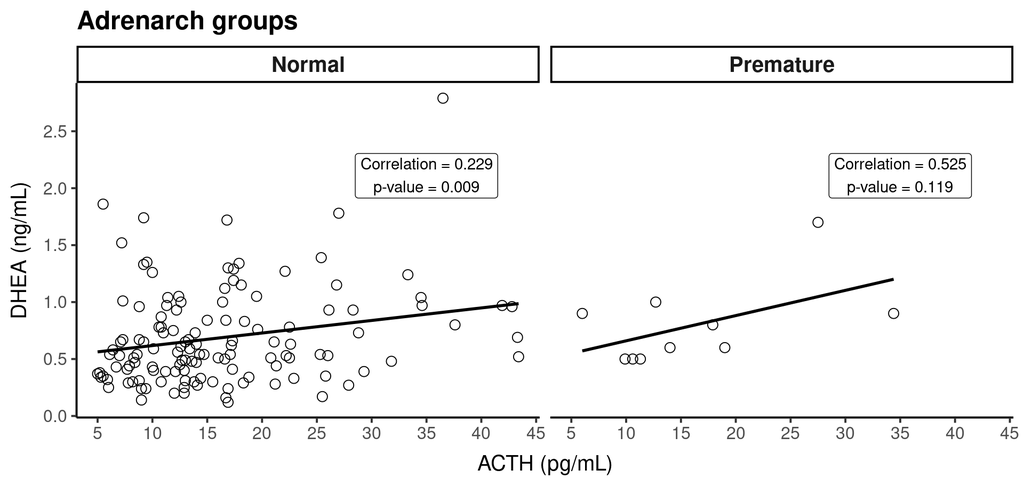

# FSH x DHEAS

> Computing and testing the correlation (Pearson’s) statistical significance, in each Adrenarch group.

| Adrenarch | Correlation | Conf.low | Conf.high | N | Statistic | p-value | Test | H1 |
| --- | --- | --- | --- | --- | --- | --- | --- | --- |
| Premature | -0.15403 | -0.71437 | 0.52668 | 10 | -0.44092 | 0.67095 | Pearson’s product-moment correlation | two.sided |
| Normal | -0.15329 | -0.31772 | 0.02010 | 129 | -1.74811 | 0.08286 | Pearson’s product-moment correlation | two.sided |

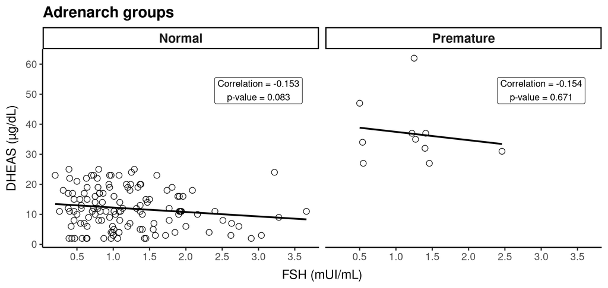

# LH x DHEAS

> Computing and testing the correlation (Pearson’s) statistical significance, in each Adrenarch group.

| Adrenarch | Correlation | Conf.low | Conf.high | N | Statistic | p-value | Test | H1 |
| --- | --- | --- | --- | --- | --- | --- | --- | --- |
| Premature | -0.37359 | -0.81217 | 0.33479 | 10 | -1.13915 | 0.28760 | Pearson’s product-moment correlation | two.sided |
| Normal | -0.05965 | -0.23013 | 0.11439 | 129 | -0.67340 | 0.50192 | Pearson’s product-moment correlation | two.sided |

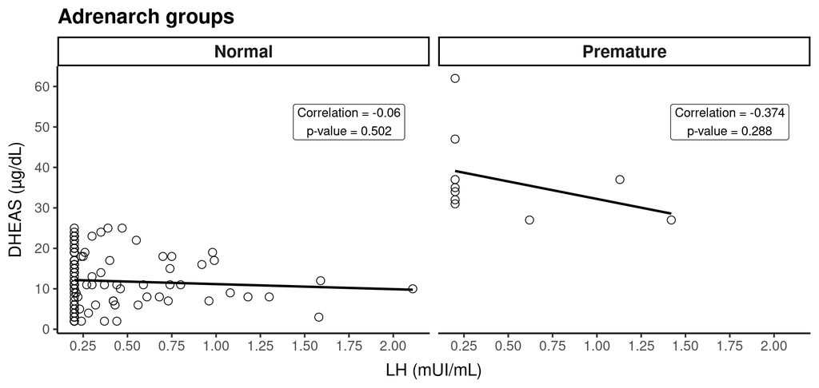

# TSH x DHEAS

> Computing and testing the correlation (Pearson’s) statistical significance, in each Adrenarch group.

| Adrenarch | Correlation | Conf.low | Conf.high | N | Statistic | p-value | Test | H1 |
| --- | --- | --- | --- | --- | --- | --- | --- | --- |
| Premature | 0.30586 | -0.40099 | 0.78442 | 10 | 0.90865 | 0.39008 | Pearson’s product-moment correlation | two.sided |
| Normal | 0.10022 | -0.07391 | 0.26842 | 129 | 1.13514 | 0.25845 | Pearson’s product-moment correlation | two.sided |

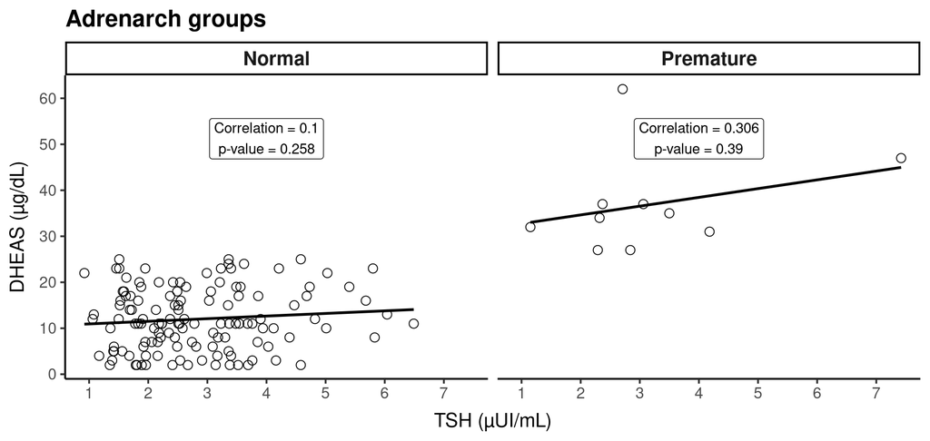

# ACTH x DHEAS

> Computing and testing the correlation (Pearson’s) statistical significance, in each Adrenarch group.

| Adrenarch | Correlation | Conf.low | Conf.high | N | Statistic | p-value | Test | H1 |
| --- | --- | --- | --- | --- | --- | --- | --- | --- |
| Premature | 0.73022 | 0.18620 | 0.93155 | 10 | 3.02301 | 0.01648 | Pearson’s product-moment correlation | two.sided |
| Normal | 0.11756 | -0.05644 | 0.28463 | 129 | 1.33406 | 0.18457 | Pearson’s product-moment correlation | two.sided |

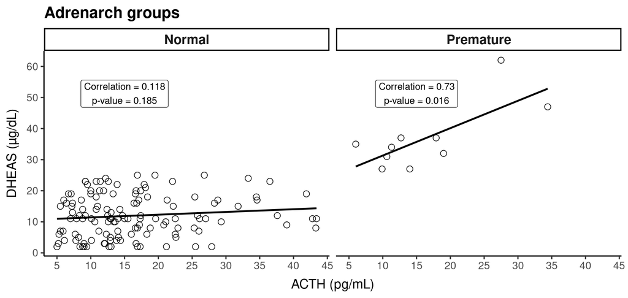

# Means

## Hormones

> The mean differences are tested under a t-test. In the first figure, we present the group means, and in the second figure its mean differences.

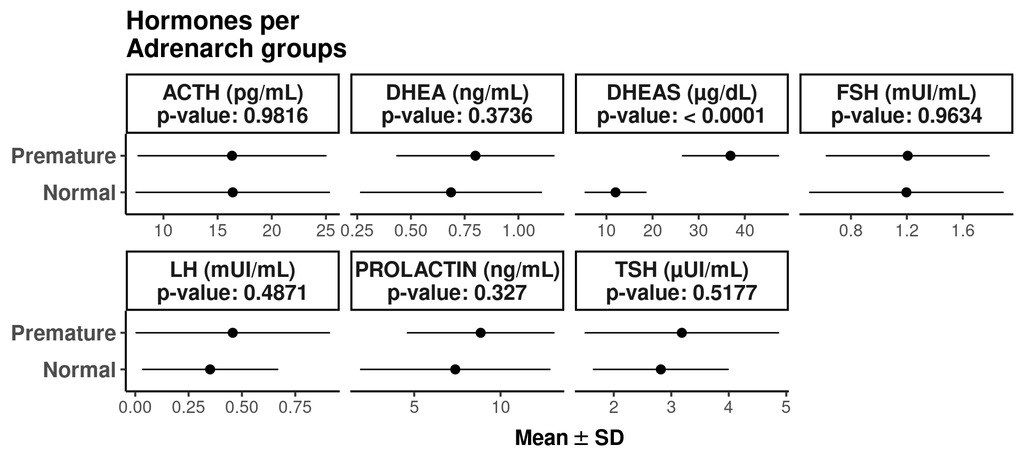

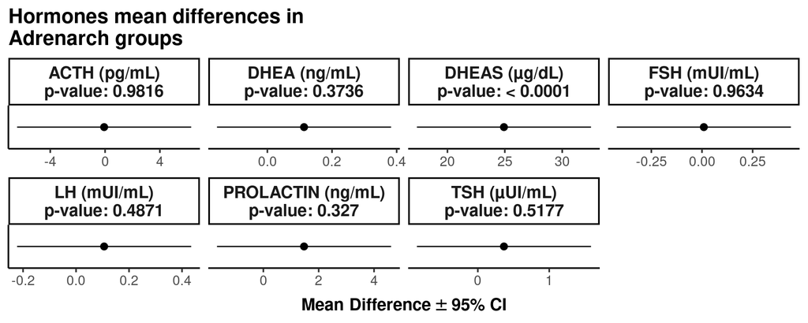

## Age & BMI

> The mean differences are tested under a t-test. In the first figure, we present the group means, and in the second figure its mean differences.

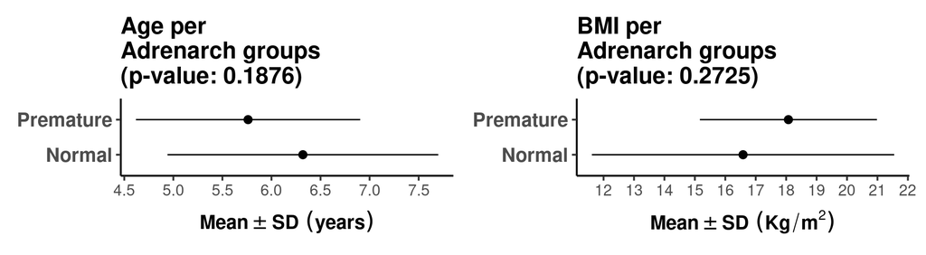

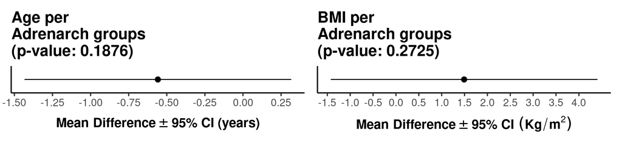

# References

> The main `R` (R Core Team, 2022) packages used in this analysis were: {`dplyr`} (Wickham et al., 2021), {`lubridate`} (Grolemund & Wickham, 2011), {`tidyr`} (Wickham, 2021), {`ggplot2`} (Wickham, 2016), {`patckwork`} (Pedersen, 2020), {`broom`} (Robinson et al., 2022), and {`purrr`} (Henry & Wickham, 2020).

> R Core Team (2022). R: A language and environment for statistical computing. R Foundation for Statistical Computing, Vienna, Austria. URL https://www.R-project.org/

> Wickham, H., François, R., Henry, L., Müller, K. (2021). dplyr: A Grammar of Data Manipulation. R package version 1.0.7. https://CRAN.R-project.org/package=dplyr

> Grolemund, G., Wickham, H. (2011). Dates and Times Made Easy wih lubridate. Journal of Statistical Software, 40(3), 1-25. URL https://www.jstatsoft.org/v40/i03/

> Wickham, H. (2021). tidyr: Tidy Messy Data. R package version 1.1.3. https://CRAN.R-project.org/package=tidyr

> Wickham, H. (2016). ggplot2: Elegant Graphics for Data Analysis. Springer-Verlag New York

> Pedersen, T. L. (2020). patchwork: The Composer of Plots. R package version 1.1.1. https://CRAN.R-project.org/package=patchwork

> Robinson, D., Hayes, A., Couch, S. (2022). broom: Convert Statistical Objects into Tidy Tibbles. R package version 0.7.12. https://CRAN.R-project.org/package=broom

> Henry, L., Wickham, H. (2020). purrr: Functional Programming Tools. R package version 0.3.4. https://CRAN.R-project.org/package=purrr